# Vorlage

Fabio Votta, Matrikelnummer 2891518

26 Oktober 2017

# Packages und Datensatz laden

```r
#install.packages("pacman")
#install.packages("haven")

pacman::p_load(tidyverse, haven)

# Datensatz einladen
#data <- read_spss("datensatz.sav")  # <- Hier Datensatz eintragen
```

Dies ist ein R-Markdown Dokument. Markdown ist eine einfache Formatierungssyntax zum Erstellen von HTML-, PDF- und MS Word-Dokumenten. Weitere Informationen zur Verwendung von R Markdown findest du unter http://rmarkdown.rstudio.com.

Wenn du auf die Schaltfläche ** Knit ** klickst, wird ein Dokument generiert, das sowohl Inhalt als auch Ausgabe von eingebetteten R-Code-Bl?cken (sogenannten chunks) innerhalb des Dokuments enth?lt. Sie k?nnen einen chunk wie folgt einbetten:

# Aufgabe 1

Zeige die ersten 6 F?lle von cars!

```r
head(cars)
```

```
##   speed dist
## 1     4    2
## 2     4   10
## 3     7    4
## 4     7   22
## 5     8   16
## 6     9   10
```

Beachte , dass dem Chunk der Parameter `results="markup"` hinzugef?gt wurde, um den Output mit zwei Hashtags an der Seite besser lesbar zu machen.

## Aufgabe 1.1

Zeige die erste Spalte von cars!

```r
cars[,1]
```

[1] 4 4 7 7 8 9 10 10 10 11 11 12 12 12 12 13 13 13 13 14 14 14 14 [24] 15 15 15 16 16 17 17 17 18 18 18 18 19 19 19 20 20 20 20 20 22 23 24 [47] 24 24 24 25

## Aufgabe 1.2

Zeige den Mittelwert von speed im cars Datensatz!

```r
mean(cars$speed)
```

[1] 15.4

## Aufgabe 1.3

Zeige eine H?ufigkeitstabelle von speed im cars Datensatz!

```r
table(cars$speed)
```

```
##
##  4  7  8  9 10 11 12 13 14 15 16 17 18 19 20 22 23 24 25
##  2  2  1  1  3  2  4  4  4  3  2  3  4  3  5  1  1  4  1
```

# Aufgabe 2

Erzeuge ein Plot von dem Objekt pressure!

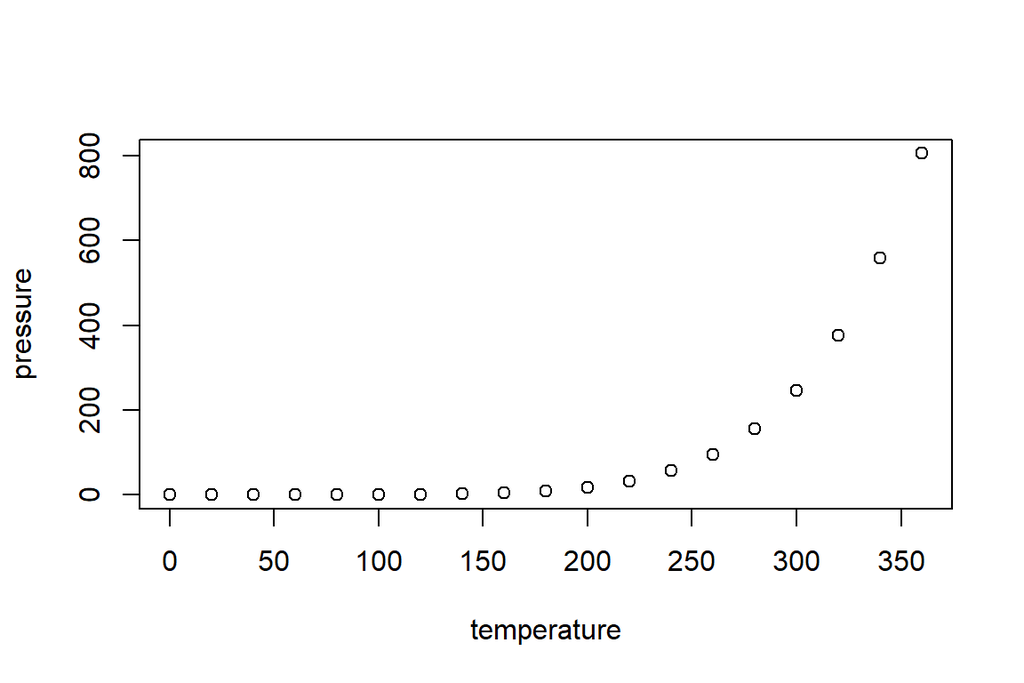

Beachte , dass dem Chunk der Parameter `echo = FALSE` hinzugef?gt wurde, um das Drucken des R-Codes zu verhindern, der den Plot generiert hat.